# Um baita teste

Fellipe Gomes

29 de janeiro de 2018

# Onde estão os blocos?

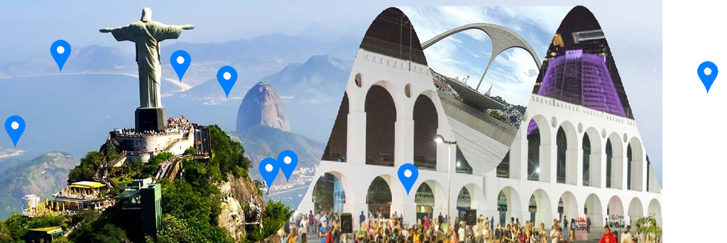

Fevereiro começando e o carnaval já está ai, especialmente se você mora no Rio de Janeiro já deve ter passado por algum bloco e a pergunta que todo mundo faz no carnaval pelo menos uma vez é: “Aonde tem bloco?”.

Baseado nessa pergunta resolvi fazer esse post especial que será bem breve, vamos utilizar os pacotes [`ggmap`](https://cran.r-project.org/package=ggmap) e [`leaflet`](https://cran.r-project.org/package=leaflet) para buscar as cordenadas geográficas do endereço dos blocos e representa-los num mapa agradável de navegar

Além disso utilizaremos o pacote [`leaflet.extras`](https://cran.r-project.org/package=leaflet.extras) que conta com muitas opções para personaliza-lo.

Ao final do post você estará pronto para criar um mapa como (ou muito melhor) que esse:

[interactive chart not shown]

# Obtendo os dados

Existem diversas maneiras de se descobrir via R informações como: aonde estão os blocos de carnaval, os endereços que ocorrem, suas cordenadas geográficas etc mas por conveniência vou utilizar essa base de dados obtida [neste link](http://www.radiosaara.com.br/noticias/carnaval-2018-lista-completa-blocos/) com informações sobre os blocos que irão ocorrer no Rio de Janeiro que já foi disponibilizada como uma planilha de excel.

Caso tenha interesse em praticar a busca por outras localidades, talvez [este post do blog curso-r sobre a API de busca do Google](http://curso-r.com/blog/2017/04/10/2017-04-13-o-que-tem-a-um-km/) e [este tópico no stackoverflow sobre como fazer a busca por localização baseado nas cordenadas (inverso da `geocode()` com `revgeocode()`)](https://stackoverflow.com/questions/37117472/loop-for-reverse-geocoding-in-r) possam ser úteis)

```r
library(readxl)
base <- read_excel("Agenda_BL_Rua_Carnaval_Rio-2018_Imprensa.xlsx")
```

## Tratamento das strings

Uma vez obtida a base de dados, os nomes das variáveis serão ajustadas de tal forma que possibilite sua manipulação. Para tal será utilizada a função `ajustar_nomes()` apresentada em um post que falo um pouco sobre [Manipulação de strings e text mining](https://gomesfellipe.github.io/post/2017-12-17-string/string/).

```r
names(base)=ajustar_nomes(names(base));names(base)
```

```
##  [1] "bloco"                   "bairro"
##  [3] "regiao"                  "data"
##  [5] "data_relativa"           "concentracao"
##  [7] "desfile"                 "final"
##  [9] "local_da_concentracao"   "percurso"
## [11] "publico_estimado"        "ano_do_primeiro_desfile"
## [13] "lon"                     "lat"
```

A seguir a limpeza das strings que carregam a informação de onde será cada bloco também precisa passar por um processo de “limpeza” para possibilitar a busca pelas localizações com a função `geocode()`.

Para esse tipo de limpeza geralmente o uso de [regex/expressão regular](https://pt.wikipedia.org/wiki/Express%C3%A3o_regular) (que nada mais é que uma ótima forma de identificar cadeias de strings) facilita muito a forma como o computador entende e processa o que desejamos execular.

Além de todo material gratuito disponível na internet com uma [simples busca no Google](https://www.google.com.br/search?q=regex&oq=regex&aqs=chrome.0.69i59l2j0l4.1259j0j7&sourceid=chrome&ie=UTF-8), para aprender a utilizar regex em suas aplicações de text mining [essa Cheatsheet](http://www.cbs.dtu.dk/courses/27610/regular-expressions-cheat-sheet-v2.pdf) pode ser útil para uma consulta rápida.

Veja a segui um exemplo de limpeza simples:

```r
base$local_da_concentracao=base$local_da_concentracao%>%
  stringr::str_trim() %>%                        #Remove espaços em branco sobrando
  stringr::str_to_lower() %>%                    #Converte todas as strings para minusculo
  rm_accent() %>%                                #Remove acentos com a funcao disponível em *
  stringr::str_replace_all("[/' '.()]", " ") %>% #Substitui os caracteres especiais por " "
  stringr::str_replace_all("_+", " ") %>%        #Substitui os caracteres especiais por " "
  stringr::str_replace("_$", " ")%>%             #Remove o caracter especiais
  stringr::str_replace(", esquina.*","")%>%      #Remove a palavra "esquina" e tudo que vier depois dela
  stringr::str_replace("n[º°].*","")%>%          #Remove as strings "nº" e "n°" e tudo que vier depois delas
  stringr::str_replace("em frente a.*","")%>%    #Remove a sentença "em frente a" e tudo que vier depois dela
  stringr::str_replace_all("[0-9]","")%>%        #Remove numeros
  stringr::str_replace_all("[:punct:]","")%>%    #Remove pontuacao
  stringr::str_c(" rio de janeiro")              #Inclui a string "rio de janeiro", que sera util em diante
base=na.omit(base)                               #Remove linhas que contenham NA
```

- [link para página do stackoverflow sobre a função `rm_accent()`](https://pt.stackoverflow.com/questions/46473/remover-acentos)

Feita a limpeza completa da base agora vamos criar uma nova coluna com a tag que irá aparecer no mapa:

```r
for(i in 1:nrow(base)){
base$label[i]=str_c("Bloco: ",base$bloco[i]," - ","Bairro: ",base$bairro[i]," - ","Regiao: ", base$regiao, "Data: ", base$data[i], " - ", "Concentração", str_sub(base$concentracao[i], start = 11)  )
}
```

## O pacote `ggmap`

Este pacote além de possuir uma coleção de funções para visualizar dados espaciais e modelos em cima de mapas estáticos de várias fontes on-line (por exemplo, Google Maps e Stamen Maps), inclui ferramentas comuns a essas tarefas, incluindo funções de geolocalização e roteamento.

Utilizaremos a funcao de giolocalização com um loop pelos endereços para obter a latitude e longitude de cada endereço e adiciona-os a base de dados em novas colunas lat e lon, veja:

```r
suppressMessages(library(ggmap))

for(i in 1:nrow(base)){
  Print("Buscando...")
  result <- geocode(base$local_da_concentracao[i], output = "latlona", source = "google")
  base$lon[i] <- as.numeric(result[1])
  base$lat[i] <- as.numeric(result[2])
}
```

Obtendo algumas cordenadas geográficas para marcar no mapa:

```r
lon_copacabana=geocode("Av. Atlantica")[1]
lat_copacabana=geocode("Av. Atlantica")[2]
lon_ipanema=geocode("Av. Vieira Souto")[1]
lat_ipanema=geocode("Av. Vieira Souto")[2]
lon_lapa=geocode("Rua da Lapa")[1]
lat_lapa=geocode("Rua da Lapa")[2]
lon_paqueta=geocode("Ilha de Paqueta")[1]
lat_paqueta=geocode("Ilha de Paqueta")[2]
```

Agora basta utilizar o pacote `leaflet` em conjunto com o pacote `leaflet.extras` para criar o mapa:

(Mais detalhes de como formatar seu mapa estão disponíveis na [página do pacote no github](https://github.com/bhaskarvk/leaflet.extras))

```r
suppressMessages(library(leaflet))
library(leaflet.extras)
base%>%
  filter(lat<(-7)&lat<(-22)&lon>(-57)&lon<(-43.1))%>% #Removendo algumas cordenadas equivocadas
  leaflet() %>%                                       #carrega o leaflet
  addTiles() %>%                                      #adiciona as camadas de mapas de acordo com o zoom
  addMarkers(lng = ~lon, lat = ~lat,popup=~label,     #mapeia a base de dados de acordo com as respectivas lat e lon
             clusterOptions = markerClusterOptions())%>%
  addResetMapButton() %>%                          #Adiciona botão para resetar mapa
  addPulseMarkers(
    lng=lon_copacabana  , lat=lat_copacabana,      #Endereço da orla de copacabana
    label='Praia de Copacabana',
    icon = makePulseIcon(heartbeat = 0.5))%>%
  addPulseMarkers(
    lng=lon_ipanema , lat=lat_ipanema,             #Endereço da orla de ipanema
    label='Praia de Ipanema',
    icon = makePulseIcon(heartbeat = 0.5))%>%
  addPulseMarkers(
    lng=lon_lapa    , lat=lat_lapa,                  #Endereço da lapa
    label='Lapa',
    icon = makePulseIcon(heartbeat = 0.5))%>%
  addPulseMarkers(
    lng=lon_paqueta , lat=lat_paqueta,             #Endereço da ilha de paquetá
    label='Ilha de Paquetá',
    icon = makePulseIcon(heartbeat = 0.5))
```

[interactive chart not shown]

Caso tenha interesse em consultar as informações da base de dados dos blocos que vão ocorrer no Rio de Janeiro para saber qual o bloco mais próximo de você e aproveitar o carnaval carioca a cunsulta pode ser feita a seguir:

[interactive chart not shown]

# Cheers !!

Além da combinação de elementos de circo, fantasias e toda a festa na rua que permite às pessoas perderem um pouco sua individualidade cotidiana e experimentarem um sentido diferente de unidade social, o carnaval envolve também a produção cultural e desfile de escolas de samba!

Dado esses diferentes aspectos de folia que envolvem o carnaval, com um olhar mais analítico a onipresença dos dados pode ser notada e por vezes conter informações relevantes.

Espero que o post tenha sido útil e desejo um bom carnaval a todos!